# LC-MS Metabolomics Data Processing

The study used in this tutorial has been previously published as an open access article [Chaleckis et al. (2016)](https://www.pnas.org/content/113/16/4252), in PNAS, and the datasets are available on MetaboLights under the ID [MTBLS265](https://www.ebi.ac.uk/metabolights/MTBLS265/descriptors).

### Summary

The data processing in this tutorial is done using [the XCMS package](https://www.bioconductor.org/packages/release/bioc/html/xcms.html), more information on the XCMS package is available in the paper by [Smith et al. (2006)](https://pubs.acs.org/doi/10.1021/ac051437y), an online version of XCMS is also available: [XCMS Online](https://xcmsonline.scripps.edu/landing_page.php?pgcontent=mainPage).

This notebook is based on the R language, multiple libraries such as XCMS, mzR, msdata are available via [Bioconductor](https://www.bioconductor.org/)

```r
#Import the libraries needed for the data processing
library(xcms)
library(msdata)
library(multtest)
library(mzR)
library(RColorBrewer)
library(pander)
library(magrittr)
library(pheatmap)
library(BiocGenerics)
library(Biobase)
library(parallel)
library(stats)
library(SummarizedExperiment)
library(scales)
```

[output not shown]

```r
# Import dataset files location (where to find the MS files in mzML format)
    # Here using MTBLS265: Individual variability in human blood metabolites identifies age-related differences (30 persons, whole blood data).
files = list.files("A:/IARC/Data/MTBLS265/sample", recursive = TRUE, full.names = TRUE)
```

## Peak detection

```r
# Construction of an xcmsSet object v1
    # DESCRIPTION: Find peaks in batch mode and pre-sorts files from subdirectories into different classes for grouping
    # METHOD: MatchedFilter methods to find peaks in the extracted chromatographic time domain of the profile matrix
xset = xcmsSet(files, method= "matchedFilter")
```

[output not shown]

```r
# XCMSset objects characteristics
xset
print("__________________________________________________________________")
```

```
An "xcmsSet" object with 8 samples

Time range: 161.9-1779.9 seconds (2.7-29.7 minutes)
Mass range: 102.0534-991.1106 m/z
Peaks: 12435 (about 1554 per sample)
Peak Groups: 0
Sample classes: sample

Feature detection:
 o Peak picking performed on MS1.
Profile settings: method = bin
                  step = 0.1

Memory usage: 1.35 MB
```

```
[1] "__________________________________________________________________"
```

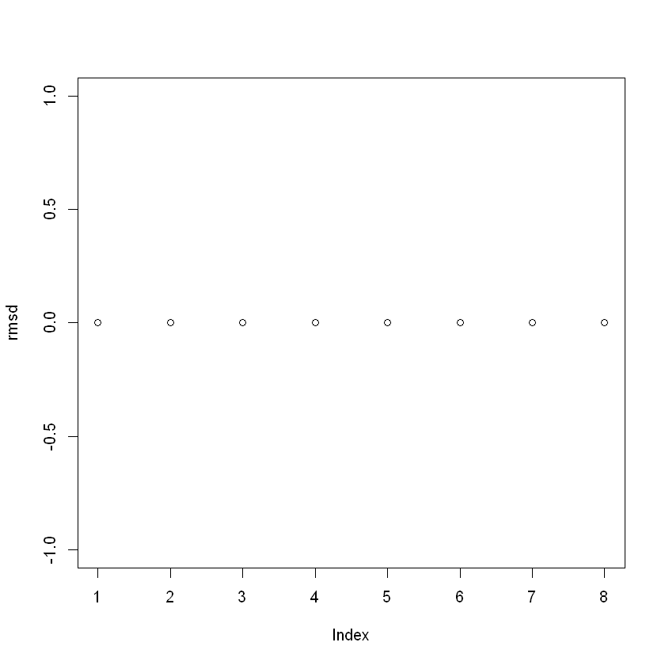

```r
#Calculation and plot of root mean squared distance (RMSD) between RT before and after correction
# Plot of XCMSset 1
rmsd = sapply(1:length(xset@rt$corrected),function(x) {sqrt(sum((xset@rt$raw[[x]]-xset@rt$corrected[[x]])**2))})
plot(rmsd)
```

## Peak grouping

```r
#Grouping peaks from different samples
xsetgroup = group(xset)
```

```
Processing 7114 mz slices ...
OK
```

## Peak alignment

```
Performing retention time correction using 742 peak groups.
```

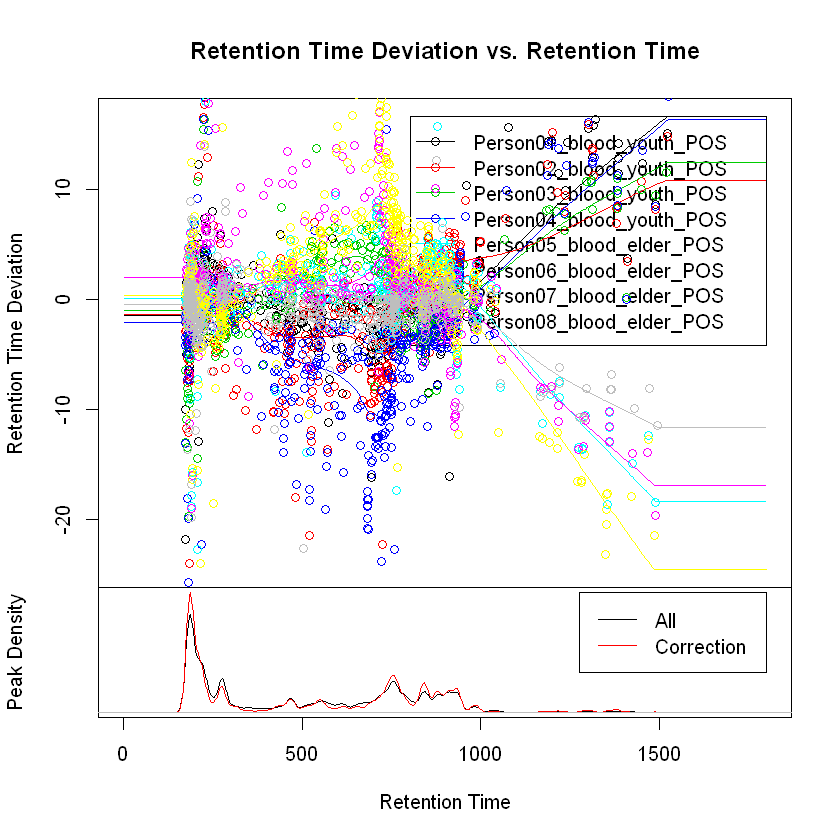

```r
#Retention time correction with symmetric method with peak grouping and result visualisation
xsg = retcor(xsetgroup,family = "symmetric", smooth = c("loess","linear"),plottype = "mdevden")
```

```r
#Retention time correction with Obiwarp and visualize the result
xsg_retcor = retcor(xset, method="obiwarp", profStep=0.1, distFunc= "cov", plottype=c("none","deviation"))
```

```
center sample:  Person07_blood_elder_POS
Processing: Person01_blood_youth_POS
```

```
Create profile matrix with method 'bin' and step 0.1 ...
OK

Create profile matrix with method 'bin' and step 0.1 ...
OK
```

```
Person02_blood_youth_POS
```

```
Create profile matrix with method 'bin' and step 0.1 ...
OK
```

```
Person03_blood_youth_POS
```

```
Create profile matrix with method 'bin' and step 0.1 ...
OK
```

```
Person04_blood_youth_POS
```

```
Create profile matrix with method 'bin' and step 0.1 ...
OK
```

```
Person05_blood_elder_POS
```

```
Create profile matrix with method 'bin' and step 0.1 ...
OK
```

```
Person06_blood_elder_POS
```

```
Create profile matrix with method 'bin' and step 0.1 ...
OK
```

```
Person08_blood_elder_POS
```

```
Create profile matrix with method 'bin' and step 0.1 ...
OK
```

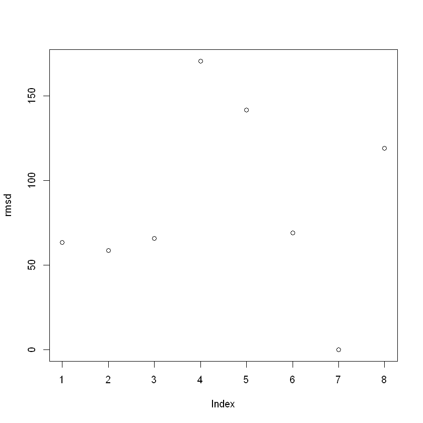

```r
# Root mean square deviation for RT corrected data and visualisation
rmsd = sapply(1:length(xsg_retcor@rt$corrected),function(x) {sqrt(sum((xsg_retcor@rt$raw[[x]]-xsg_retcor@rt$corrected[[x]])**2))})
plot(rmsd)
```

```r
# Grouping peaks after RT correction with ObiWarp
xsg_retcor_group = group(xsg_retcor,bw=10)
```

```
Processing 7114 mz slices ...
OK
```

## Filling missing features

```r
# Filling back missing peaks in the dataset
xsg_retcor_group_fill = fillPeaks(xsg_retcor_group, nSlaves=2,expand.mz=1,expand.rt=1)
```

[output not shown]

## Output

```r
# Extract peak table from the processed data
peaks = peakTable(xsg_retcor_group_fill)
```

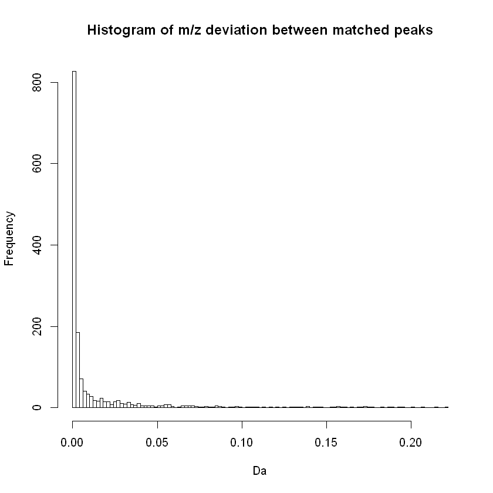

```r
# Histogram visualisation of the m/z deviation between the matched peaks
hist(peaks$mzmax-peaks$mzmin,100, xlab = "Da",
     main="Histogram of m/z deviation between matched peaks")
```